# Caso Practico Final

Alfred Burquier Reyes

22 de marzo de 2019

## PREGUNTAS

Tomaremos el dataset de aprobación de crédito bancario en https://archive.ics.uci.edu/ml/datasets/Credit+Approval .

1.- Carga los datos. Realiza una inspección por variables de la distribución de aprobación de crédito en función de cada atributo visualmente. Realiza las observaciones pertinentes. ¿ Qué variables son mejores para separar los datos?.

2.- Prepara el dataset convenientemente e imputa los valores faltantes usando la librería missForest.

3.- Divide el dataset tomando las primeras 590 instancias como train y las últimas 100 como test.

4.- Entrena un modelo de regresión logística con regularización Ridge y Lasso en train. seleccionando el que mejor AUC tenga. Da las métricas en test.

5.- Aporta los log odds de las variables predictoras sobre la variable objetivo.

6.- Si por cada verdadero positivo ganamos 100e y por cada falso positivo perdemos 20e. ¿ Qué rentabilidad aporta aplicar este modelo?.

# 1.- Carga los datos. Realiza una inspección por variables de la distribución de aprobación de crédito en función de cada atributo visualmente. Realiza las observaciones pertinentes. ¿ Qué variables son mejores para separar los datos?.

```r
url <- "https://archive.ics.uci.edu/ml/machine-learning-databases/credit-screening/crx.data"
crx <- read.csv(url,na.strings = "?", header = FALSE)
write.csv(crx, file='crx.csv')
dim(crx)
```

```
## [1] 690  16
```

```r
str(crx)
```

```
## 'data.frame':    690 obs. of  16 variables:
##  $ V1 : Factor w/ 2 levels "a","b": 2 1 1 2 2 2 2 1 2 2 ...
##  $ V2 : num  30.8 58.7 24.5 27.8 20.2 ...
##  $ V3 : num  0 4.46 0.5 1.54 5.62 ...
##  $ V4 : Factor w/ 3 levels "l","u","y": 2 2 2 2 2 2 2 2 3 3 ...
##  $ V5 : Factor w/ 3 levels "g","gg","p": 1 1 1 1 1 1 1 1 3 3 ...
##  $ V6 : Factor w/ 14 levels "aa","c","cc",..: 13 11 11 13 13 10 12 3 9 13 ...
##  $ V7 : Factor w/ 9 levels "bb","dd","ff",..: 8 4 4 8 8 8 4 8 4 8 ...
##  $ V8 : num  1.25 3.04 1.5 3.75 1.71 ...
##  $ V9 : Factor w/ 2 levels "f","t": 2 2 2 2 2 2 2 2 2 2 ...
##  $ V10: Factor w/ 2 levels "f","t": 2 2 1 2 1 1 1 1 1 1 ...
##  $ V11: int  1 6 0 5 0 0 0 0 0 0 ...
##  $ V12: Factor w/ 2 levels "f","t": 1 1 1 2 1 2 2 1 1 2 ...
##  $ V13: Factor w/ 3 levels "g","p","s": 1 1 1 1 3 1 1 1 1 1 ...
##  $ V14: int  202 43 280 100 120 360 164 80 180 52 ...
##  $ V15: int  0 560 824 3 0 0 31285 1349 314 1442 ...
##  $ V16: Factor w/ 2 levels "-","+": 2 2 2 2 2 2 2 2 2 2 ...
```

```r
summary(crx)
```

```
##     V1            V2              V3            V4         V5
##  a   :210   Min.   :13.75   Min.   : 0.000   l   :  2   g   :519
##  b   :468   1st Qu.:22.60   1st Qu.: 1.000   u   :519   gg  :  2
##  NA's: 12   Median :28.46   Median : 2.750   y   :163   p   :163
##             Mean   :31.57   Mean   : 4.759   NA's:  6   NA's:  6
##             3rd Qu.:38.23   3rd Qu.: 7.207
##             Max.   :80.25   Max.   :28.000
##             NA's   :12
##        V6            V7            V8         V9      V10
##  c      :137   v      :399   Min.   : 0.000   f:329   f:395
##  q      : 78   h      :138   1st Qu.: 0.165   t:361   t:295
##  w      : 64   bb     : 59   Median : 1.000
##  i      : 59   ff     : 57   Mean   : 2.223
##  aa     : 54   j      :  8   3rd Qu.: 2.625
##  (Other):289   (Other): 20   Max.   :28.500
##  NA's   :  9   NA's   :  9
##       V11       V12     V13          V14            V15           V16
##  Min.   : 0.0   f:374   g:625   Min.   :   0   Min.   :     0.0   -:383
##  1st Qu.: 0.0   t:316   p:  8   1st Qu.:  75   1st Qu.:     0.0   +:307
##  Median : 0.0           s: 57   Median : 160   Median :     5.0
##  Mean   : 2.4                   Mean   : 184   Mean   :  1017.4
##  3rd Qu.: 3.0                   3rd Qu.: 276   3rd Qu.:   395.5
##  Max.   :67.0                   Max.   :2000   Max.   :100000.0
##                                 NA's   :13
```

# 2.- Prepara el dataset convenientemente e imputa los valores faltantes usando la librería missForest.

```r
#install.packages("missForest", dependencies = TRUE)
library(missForest)
crx.imp <- missForest(crx) # Cargo el dataset crx en missForest
```

```
##   missForest iteration 1 in progress...done!
##   missForest iteration 2 in progress...done!
##   missForest iteration 3 in progress...done!
##   missForest iteration 4 in progress...done!
##   missForest iteration 5 in progress...done!
##   missForest iteration 6 in progress...done!
##   missForest iteration 7 in progress...done!
##   missForest iteration 8 in progress...done!
##   missForest iteration 9 in progress...done!
##   missForest iteration 10 in progress...done!
```

```r
#crx.imp$ximp
crx.imp$OOBerror #OOB indicar el error, NRMSE es el error cuadratico medio normalizado (entre mas cercano a 0 este valor mejor el rendimiento) y PFC es la proporcion de entradas faltantes clasificadas
```

```
##      NRMSE        PFC
## 0.03149499 0.13258485
```

```r
crx2 <- crx.imp$ximp # crx2 es el nuevo dataset sin valores nulos.
summary(crx2)
```

```
##  V1            V2              V3         V4       V5            V6
##  a:214   Min.   :13.75   Min.   : 0.000   l:  2   g :525   c      :137
##  b:476   1st Qu.:22.67   1st Qu.: 1.000   u:525   gg:  2   q      : 78
##          Median :28.58   Median : 2.750   y:163   p :163   w      : 64
##          Mean   :31.60   Mean   : 4.759                    i      : 61
##          3rd Qu.:38.23   3rd Qu.: 7.207                    ff     : 55
##          Max.   :80.25   Max.   :28.000                    aa     : 54
##                                                            (Other):241
##        V7            V8         V9      V10          V11       V12
##  v      :400   Min.   : 0.000   f:329   f:395   Min.   : 0.0   f:374
##  h      :138   1st Qu.: 0.165   t:361   t:295   1st Qu.: 0.0   t:316
##  bb     : 61   Median : 1.000                   Median : 0.0
##  ff     : 59   Mean   : 2.223                   Mean   : 2.4
##  j      :  9   3rd Qu.: 2.625                   3rd Qu.: 3.0
##  z      :  9   Max.   :28.500                   Max.   :67.0
##  (Other): 14
##  V13          V14              V15           V16
##  g:625   Min.   :   0.0   Min.   :     0.0   -:383
##  p:  8   1st Qu.:  80.0   1st Qu.:     0.0   +:307
##  s: 57   Median : 160.0   Median :     5.0
##          Mean   : 183.6   Mean   :  1017.4
##          3rd Qu.: 272.0   3rd Qu.:   395.5
##          Max.   :2000.0   Max.   :100000.0
##
```

```r
dim(crx2)
```

```
## [1] 690  16
```

# 3.- Divide el dataset tomando las primeras 590 instancias como train y las últimas 100 como test.

```r
crx2$V16 <- as.numeric(crx2$V16) -1
crx2_train <- crx2[1:590, 1:16]
crx2_test <- crx2[591:690, 1:16]
X <- crx2[,1:15]
y <- crx2$V16
unique(y)
```

```
## [1] 1 0
```

```r
X_train <- X[1:590,]
y_train <- y[1:590]
X_test <- X[591:690,]
y_test <- y[591:690]
```

Se dividio el dataset crx2 en primeras 590 instancias como X_train y y_train, las últimas 100 como X_test y y_test.

# 4.- Entrena un modelo de regresión logística con regularización Ridge y Lasso en train. seleccionando el que mejor AUC tenga. Da las métricas en test.

Primero realizare una regresion logistica mediante AIC.

```r
#help("glm")
fit1 <- glm(V16~., data=crx2, family=binomial)
summary(fit1)
```

```
##
## Call:
## glm(formula = V16 ~ ., family = binomial, data = crx2)
##
## Deviance Residuals:
##     Min       1Q   Median       3Q      Max
## -2.5905  -0.3042  -0.1317   0.3949   3.4174
##
## Coefficients: (2 not defined because of singularities)
##               Estimate Std. Error z value Pr(>|z|)
## (Intercept)  1.066e+01  7.489e+02   0.014  0.98864
## V1b         -1.249e-01  3.166e-01  -0.395  0.69318
## V2           1.230e-02  1.355e-02   0.907  0.36430
## V3          -2.060e-02  2.883e-02  -0.714  0.47493
## V4u         -1.440e+01  7.489e+02  -0.019  0.98466
## V4y         -1.525e+01  7.489e+02  -0.020  0.98375
## V5gg                NA         NA      NA       NA
## V5p                 NA         NA      NA       NA
## V6c          3.368e-01  5.134e-01   0.656  0.51180
## V6cc         1.521e+00  7.669e-01   1.984  0.04728 *
## V6d          2.083e-01  7.854e-01   0.265  0.79086
## V6e          2.077e+00  1.155e+00   1.799  0.07205 .
## V6ff        -3.323e+00  2.162e+00  -1.537  0.12429
## V6i         -1.308e-01  7.028e-01  -0.186  0.85235
## V6j         -3.941e+00  2.248e+00  -1.754  0.07951 .
## V6k         -2.388e-01  6.298e-01  -0.379  0.70454
## V6m          2.862e-01  6.905e-01   0.414  0.67853
## V6q          4.890e-01  5.637e-01   0.867  0.38568
## V6r         -1.657e+00  4.398e+00  -0.377  0.70630
## V6w          9.933e-01  5.783e-01   1.718  0.08587 .
## V6x          2.886e+00  9.203e-01   3.136  0.00171 **
## V7dd        -1.361e+00  1.599e+00  -0.851  0.39494
## V7ff         2.281e+00  2.075e+00   1.099  0.27163
## V7h          6.881e-01  5.684e-01   1.211  0.22605
## V7j          4.726e+00  2.152e+00   2.196  0.02808 *
## V7n          3.242e+00  1.587e+00   2.043  0.04101 *
## V7o         -3.104e+01  4.745e+07   0.000  1.00000
## V7v          4.258e-01  5.251e-01   0.811  0.41744
## V7z         -3.616e+00  1.595e+00  -2.267  0.02336 *
## V8           6.676e-02  4.918e-02   1.357  0.17468
## V9t          3.764e+00  3.499e-01  10.758  < 2e-16 ***
## V10t         6.014e-01  3.715e-01   1.619  0.10544
## V11          1.224e-01  5.796e-02   2.111  0.03473 *
## V12t        -2.771e-01  2.824e-01  -0.981  0.32642
## V13p         3.884e+00  9.573e-01   4.057 4.97e-05 ***
## V13s        -2.870e-02  4.915e-01  -0.058  0.95343
## V14         -2.681e-03  9.172e-04  -2.923  0.00347 **
## V15          5.592e-04  1.851e-04   3.021  0.00252 **
## ---
## Signif. codes:  0 '***' 0.001 '**' 0.01 '*' 0.05 '.' 0.1 ' ' 1
##
## (Dispersion parameter for binomial family taken to be 1)
##
##     Null deviance: 948.16  on 689  degrees of freedom
## Residual deviance: 391.23  on 654  degrees of freedom
## AIC: 463.23
##
## Number of Fisher Scoring iterations: 14
```

```r
fit0 <- glm(V16~1, data=crx2, family=binomial)
summary(fit0)
```

```
##
## Call:
## glm(formula = V16 ~ 1, family = binomial, data = crx2)
##
## Deviance Residuals:
##    Min      1Q  Median      3Q     Max
## -1.085  -1.085  -1.085   1.273   1.273
##
## Coefficients:
##             Estimate Std. Error z value Pr(>|z|)
## (Intercept)  -0.2212     0.0766  -2.887  0.00388 **
## ---
## Signif. codes:  0 '***' 0.001 '**' 0.01 '*' 0.05 '.' 0.1 ' ' 1
##
## (Dispersion parameter for binomial family taken to be 1)
##
##     Null deviance: 948.16  on 689  degrees of freedom
## Residual deviance: 948.16  on 689  degrees of freedom
## AIC: 950.16
##
## Number of Fisher Scoring iterations: 3
```

```r
library(MASS)
step <-stepAIC(fit0,direction="forward",scope=list(upper=fit1,lower=fit0))
```

```
## Start:  AIC=950.16
## V16 ~ 1
```

```
##        Df Deviance    AIC
## + V9    1   540.95 544.95
## + V11   1   762.74 766.74
## + V10   1   798.66 802.66
## + V15   1   862.80 866.80
## + V8    1   863.32 867.32
## + V6   13   846.67 874.67
## + V7    8   903.03 921.03
## + V3    1   918.36 922.36
## + V4    2   919.84 925.84
## + V5    2   919.84 925.84
## + V2    1   930.04 934.04
## + V13   2   938.55 944.55
## + V14   1   940.61 944.61
## <none>      948.16 950.16
## + V12   1   947.47 951.47
## + V1    1   947.76 951.76
##
## Step:  AIC=544.95
## V16 ~ V9
```

```
##        Df Deviance    AIC
## + V11   1   503.21 509.21
## + V15   1   505.09 511.09
## + V10   1   507.67 513.67
## + V4    2   518.66 526.66
## + V5    2   518.66 526.66
## + V13   2   521.04 529.04
## + V6   13   505.45 535.45
## + V8    1   532.97 538.97
## + V14   1   536.43 542.43
## + V7    8   524.59 544.59
## <none>      540.95 544.95
## + V12   1   539.26 545.26
## + V3    1   539.69 545.69
## + V1    1   540.64 546.64
## + V2    1   540.70 546.70
##
## Step:  AIC=509.21
## V16 ~ V9 + V11
```

```
##        Df Deviance    AIC
## + V15   1   477.87 485.87
## + V13   2   484.00 494.00
## + V4    2   484.15 494.15
## + V5    2   484.15 494.15
## + V6   13   470.46 502.46
## + V10   1   498.33 506.33
## + V7    8   484.65 506.65
## + V8    1   499.68 507.68
## <none>      503.21 509.21
## + V14   1   501.42 509.42
## + V12   1   501.99 509.99
## + V1    1   503.16 511.16
## + V2    1   503.17 511.17
## + V3    1   503.19 511.19
```

```
##
## Step:  AIC=485.87
## V16 ~ V9 + V11 + V15
```

```
##        Df Deviance    AIC
## + V13   2   462.37 474.37
## + V5    2   464.59 476.59
## + V4    2   464.59 476.59
## + V6   13   446.26 480.26
## + V10   1   473.35 483.35
## + V8    1   473.93 483.93
## + V7    8   461.56 485.56
## + V14   1   475.58 485.58
## <none>      477.87 485.87
## + V12   1   476.52 486.52
## + V3    1   477.73 487.73
## + V2    1   477.81 487.81
## + V1    1   477.82 487.82
```

```
##
## Step:  AIC=474.37
## V16 ~ V9 + V11 + V15 + V13
```

```
##        Df Deviance    AIC
## + V5    2   449.66 465.66
## + V4    2   449.66 465.66
## + V6   13   429.42 467.42
## + V10   1   456.49 470.49
## + V8    1   457.91 471.91
## + V14   1   460.28 474.28
## <none>      462.37 474.37
## + V7    8   447.01 475.01
## + V12   1   461.69 475.69
## + V2    1   462.13 476.13
## + V1    1   462.30 476.30
## + V3    1   462.36 476.36
```

```
##
## Step:  AIC=465.66
## V16 ~ V9 + V11 + V15 + V13 + V5
```

```
##        Df Deviance    AIC
## + V6   13   419.24 461.24
## + V10   1   444.44 462.44
## + V7    8   431.42 463.42
## + V8    1   446.69 464.69
## + V14   1   446.92 464.92
## <none>      449.66 465.66
## + V12   1   448.79 466.79
## + V2    1   449.22 467.22
## + V1    1   449.62 467.62
## + V3    1   449.63 467.63
```

```
##
## Step:  AIC=461.24
## V16 ~ V9 + V11 + V15 + V13 + V5 + V6
```

```
##        Df Deviance    AIC
## + V14   1   411.43 455.43
## + V10   1   416.59 460.59
## <none>      419.24 461.24
## + V8    1   417.82 461.82
## + V12   1   417.90 461.90
## + V1    1   419.14 463.14
## + V2    1   419.15 463.15
## + V3    1   419.18 463.18
## + V7    8   407.47 465.47
```

```
##
## Step:  AIC=455.43
## V16 ~ V9 + V11 + V15 + V13 + V5 + V6 + V14
```

```
##        Df Deviance    AIC
## + V10   1   408.90 454.90
## <none>      411.43 455.43
## + V8    1   410.13 456.13
## + V3    1   410.78 456.78
## + V12   1   410.82 456.82
## + V2    1   411.36 457.36
## + V1    1   411.39 457.39
## + V7    8   398.26 458.26
```

```
##
## Step:  AIC=454.9
## V16 ~ V9 + V11 + V15 + V13 + V5 + V6 + V14 + V10
```

```
##        Df Deviance    AIC
## <none>      408.90 454.90
## + V8    1   407.41 455.41
## + V3    1   408.38 456.38
## + V12   1   408.51 456.51
## + V2    1   408.68 456.68
## + V1    1   408.88 456.88
## + V7    8   395.58 457.58
```

```r
summary(step)
```

```
##
## Call:
## glm(formula = V16 ~ V9 + V11 + V15 + V13 + V5 + V6 + V14 + V10,
##     family = binomial, data = crx2)
##
## Deviance Residuals:
##     Min       1Q   Median       3Q      Max
## -2.6311  -0.3282  -0.1554   0.4262   3.0875
##
## Coefficients:
##               Estimate Std. Error z value Pr(>|z|)
## (Intercept) -3.092e+00  5.016e-01  -6.164 7.10e-10 ***
## V9t          3.641e+00  3.134e-01  11.619  < 2e-16 ***
## V11          1.148e-01  5.657e-02   2.029 0.042422 *
## V15          5.252e-04  1.726e-04   3.043 0.002344 **
## V13p         3.848e+00  8.905e-01   4.321 1.55e-05 ***
## V13s         1.660e-01  4.670e-01   0.356 0.722194
## V5gg         1.602e+01  6.744e+02   0.024 0.981044
## V5p         -8.145e-01  3.197e-01  -2.547 0.010855 *
## V6c          4.355e-01  4.800e-01   0.907 0.364234
## V6cc         1.618e+00  7.214e-01   2.243 0.024896 *
## V6d          1.378e-01  7.482e-01   0.184 0.853894
## V6e          2.858e-01  7.584e-01   0.377 0.706274
## V6ff        -1.217e+00  7.136e-01  -1.706 0.088072 .
## V6i         -3.060e-01  5.980e-01  -0.512 0.608874
## V6j          1.938e-01  1.104e+00   0.175 0.860720
## V6k         -1.154e-01  5.960e-01  -0.194 0.846461
## V6m          2.687e-01  6.529e-01   0.412 0.680635
## V6q          6.538e-01  5.362e-01   1.219 0.222707
## V6r          9.882e-01  3.706e+00   0.267 0.789732
## V6w          9.102e-01  5.534e-01   1.645 0.100031
## V6x          2.839e+00  8.570e-01   3.313 0.000922 ***
## V14         -2.296e-03  8.409e-04  -2.731 0.006322 **
## V10t         5.785e-01  3.625e-01   1.596 0.110535
## ---
## Signif. codes:  0 '***' 0.001 '**' 0.01 '*' 0.05 '.' 0.1 ' ' 1
##
## (Dispersion parameter for binomial family taken to be 1)
##
##     Null deviance: 948.16  on 689  degrees of freedom
## Residual deviance: 408.90  on 667  degrees of freedom
## AIC: 454.9
##
## Number of Fisher Scoring iterations: 14
```

El mejor modelo de regresión logística con AIC es V16 ~ V9 + V11 + V15 + V13 + V5 + V6 + V14 + V10

```r
y_pred <- as.numeric(predict(step, X_test)>.5)
#install.packages(c("e1071", "caret", "ggplot2","lattice","class","gmodels"))
library(caret)
library(ggplot2)
library(lattice)
library(e1071)
library(class)
library(gmodels)
#help("confusionMatrix") #La matriz de confusión y las métricas de erorr se pueden calcular. Para obtener todas las que se han dado incluir la opción mode="everything"
confusionMatrix(table(y_test,y_pred), mode="everything")
```

```
## Confusion Matrix and Statistics
##
##       y_pred
## y_test  0  1
##      0 85  1
##      1  6  8
##
##                Accuracy : 0.93
##                  95% CI : (0.8611, 0.9714)
##     No Information Rate : 0.91
##     P-Value [Acc > NIR] : 0.3128
##
##                   Kappa : 0.6582
##  Mcnemar's Test P-Value : 0.1306
##
##             Sensitivity : 0.9341
##             Specificity : 0.8889
##          Pos Pred Value : 0.9884
##          Neg Pred Value : 0.5714
##               Precision : 0.9884
##                  Recall : 0.9341
##                      F1 : 0.9605
##              Prevalence : 0.9100
##          Detection Rate : 0.8500
##    Detection Prevalence : 0.8600
##       Balanced Accuracy : 0.9115
##
##        'Positive' Class : 0
##
```

Efectuaremos las regresiones logísticas con regularización Ridge y Lasso.

Regresión logística con regularización Ridge

```r
X_train2 <- data.matrix(X_train)
X_test2 <- data.matrix(X_test)
#install.packages("glmnet")
library(glmnet)
set.seed(999)
cv.ridge <- cv.glmnet(X_train2, y_train, family='binomial', alpha=0, parallel=TRUE, standardize=TRUE, type.measure='auc')
```

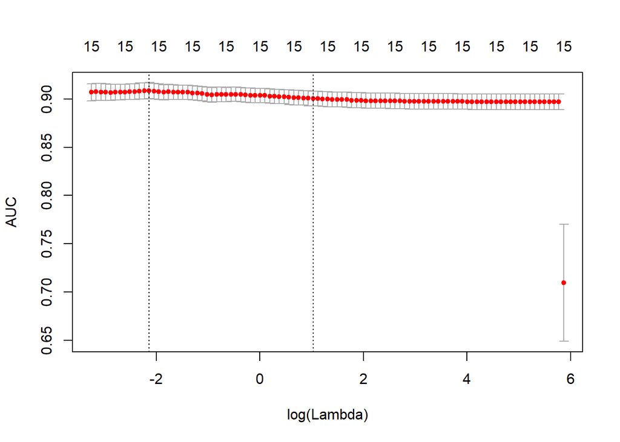

```r
plot(cv.ridge) # Resultados
```

```r
cv.ridge$lambda.min #este es el mejor valor de lambda
```

```
## [1] 0.1181697
```

```r
max(cv.ridge$cvm) #este es el valor del error que se estima para ese valor lambda mínimo dado en MSE
```

```
## [1] 0.908672
```

```r
coef(cv.ridge, s=cv.ridge$lambda.min) #coeficientes
```

```
## 16 x 1 sparse Matrix of class "dgCMatrix"
##                         1
## (Intercept) -3.372660e+00
## V1          -4.037662e-02
## V2           2.072767e-03
## V3           1.441918e-02
## V4          -2.701155e-01
## V5          -8.698003e-02
## V6           2.893605e-02
## V7           8.652102e-03
## V8           6.203332e-02
## V9           1.702700e+00
## V10          6.415148e-01
## V11          5.638080e-02
## V12         -8.838836e-03
## V13         -8.713251e-02
## V14         -5.961454e-04
## V15          3.687334e-05
```

```r
#métricas en el test
y_pred2 <- as.numeric(predict.glmnet(cv.ridge$glmnet.fit, newx=X_test2, s=cv.ridge$lambda.min)>.5)
confusionMatrix(table(y_test,y_pred2), mode="everything")
```

```
## Confusion Matrix and Statistics
##
##       y_pred2
## y_test  0  1
##      0 86  0
##      1  8  6
##
##                Accuracy : 0.92
##                  95% CI : (0.8484, 0.9648)
##     No Information Rate : 0.94
##     P-Value [Acc > NIR] : 0.85371
##
##                   Kappa : 0.5633
##  Mcnemar's Test P-Value : 0.01333
##
##             Sensitivity : 0.9149
##             Specificity : 1.0000
##          Pos Pred Value : 1.0000
##          Neg Pred Value : 0.4286
##               Precision : 1.0000
##                  Recall : 0.9149
##                      F1 : 0.9556
##              Prevalence : 0.9400
##          Detection Rate : 0.8600
##    Detection Prevalence : 0.8600
##       Balanced Accuracy : 0.9574
##
##        'Positive' Class : 0
##
```

Regresión logística con regularización Lasso

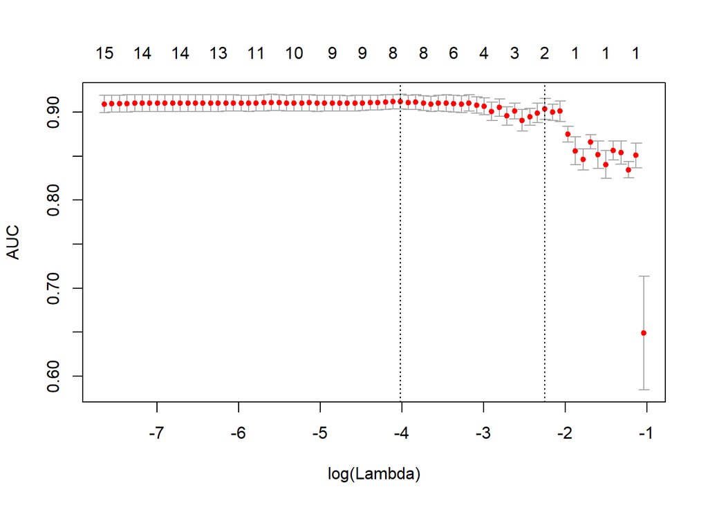

```r
set.seed(999)
cv.lasso <- cv.glmnet(X_train2, y_train, family='binomial', alpha=1, parallel=TRUE, standardize=TRUE, type.measure='auc')
plot(cv.lasso)# Resultados
```

```r
cv.lasso$lambda.min #este es el mejor valor de lambda
```

```
## [1] 0.01796074
```

```r
max(cv.lasso$cvm)#este es el valor del error que se estima para ese valor lambda mínimo dado en MSE
```

```
## [1] 0.9120709
```

```r
coef(cv.lasso, s=cv.lasso$lambda.min) #coeficientes
```

```
## 16 x 1 sparse Matrix of class "dgCMatrix"
##                         1
## (Intercept) -5.517932e+00
## V1           .
## V2           .
## V3           .
## V4          -3.818308e-01
## V5           .
## V6           1.833717e-02
## V7           .
## V8           3.632492e-02
## V9           3.027175e+00
## V10          7.138721e-01
## V11          6.234377e-02
## V12          .
## V13          .
## V14         -4.325757e-04
## V15          4.669514e-05
```

```r
y_pred3 <- as.numeric(predict.glmnet(cv.lasso$glmnet.fit, newx=X_test2, s=cv.lasso$lambda.min)>.5)
confusionMatrix(table(y_test,y_pred3), mode="everything")
```

```
## Confusion Matrix and Statistics
##
##       y_pred3
## y_test  0  1
##      0 85  1
##      1  7  7
##
##                Accuracy : 0.92
##                  95% CI : (0.8484, 0.9648)
##     No Information Rate : 0.92
##     P-Value [Acc > NIR] : 0.5926
##
##                   Kappa : 0.5951
##  Mcnemar's Test P-Value : 0.0771
##
##             Sensitivity : 0.9239
##             Specificity : 0.8750
##          Pos Pred Value : 0.9884
##          Neg Pred Value : 0.5000
##               Precision : 0.9884
##                  Recall : 0.9239
##                      F1 : 0.9551
##              Prevalence : 0.9200
##          Detection Rate : 0.8500
##    Detection Prevalence : 0.8600
##       Balanced Accuracy : 0.8995
##
##        'Positive' Class : 0
##
```